# An Aging Population and Fire Mortality

Matt Wakefield

October 17, 2018

# Population Trends

You will notice how not only will older Americans grow as a percentage of the populations, but those between the ages of 5 and 35 will decrease as a percentage of the population.

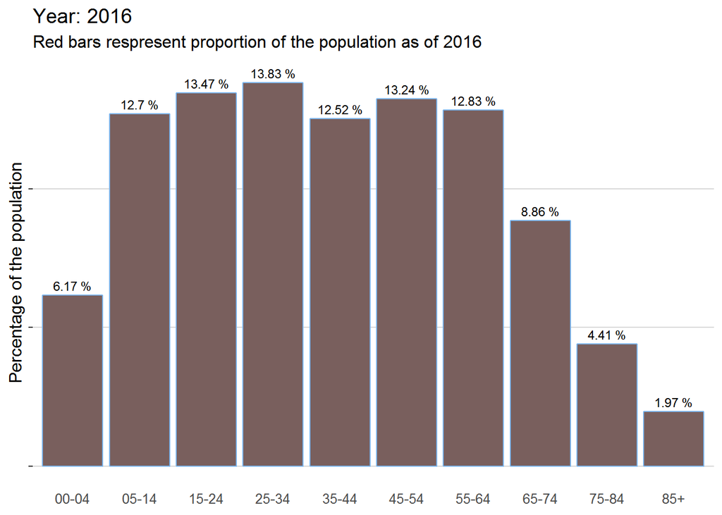

# Mortality Trends

According to data provided by the USFA, those over the age of 75 are more than three times as likely to die in a fire while those between the ages of 5 and 35 are are 1/3 as likely to die in a fire.

Below you will see that although these mortality rates change overtime, their relationship with one another does not.

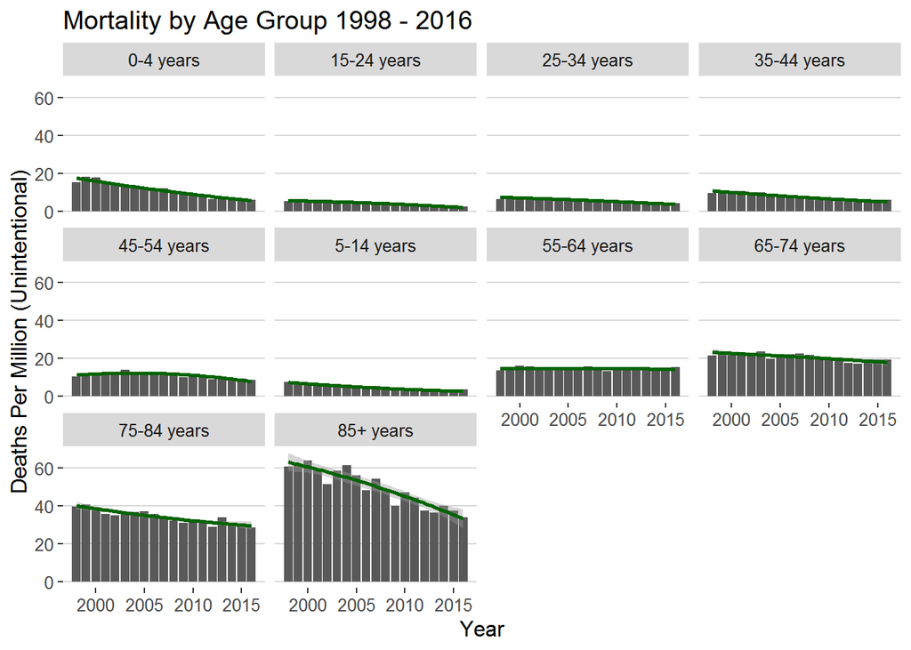

## Fire Causes

The causes of fires that lead to fatalities, do not hit all age brackets evenly.

According to the NFPA, Smoking was the leading cause of death for those over the age of 65. Smoking represented 34% of fatalities for those over the age of 65 while accounting for only 22% of fatalities for the entire population.

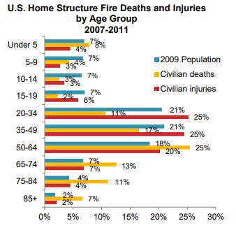

https://www.nfpa.org/-/media/Files/News-and-Research/Fire-statistics-and-reports/Fact-sheets/HomeVictimsFactSheet.ashx?la=en

# Putting It All Together

Using these two pieces of information, the proportion of adults over the age of 75 is growing, and the mortality rate of these older adults is higher, we can estimate the effects this will have on mortality rate.

The mortality rate was forecasted by multiplying the 2012-2016 average mortality rate for each of the age brackets by the projected population in each of those age brackets. The result confirms what we’ve already begun to observe, the mortality rate is beginning to level off and may even rise slightly as our population becomes older.

This trend continues into 2060 in part because of longer life spans but also because two of the largest generations ever, Baby Boomers and Millennials, will be aging into the highest risk age brackets.

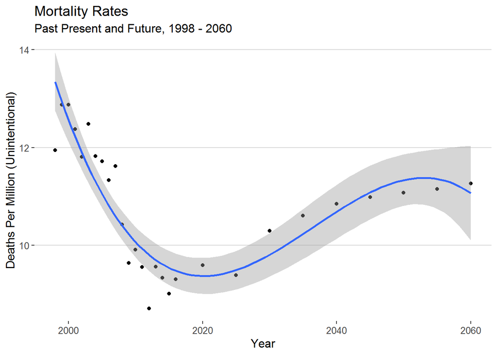

This trend is compounded when you look at raw fatalities due to the overall growing population.

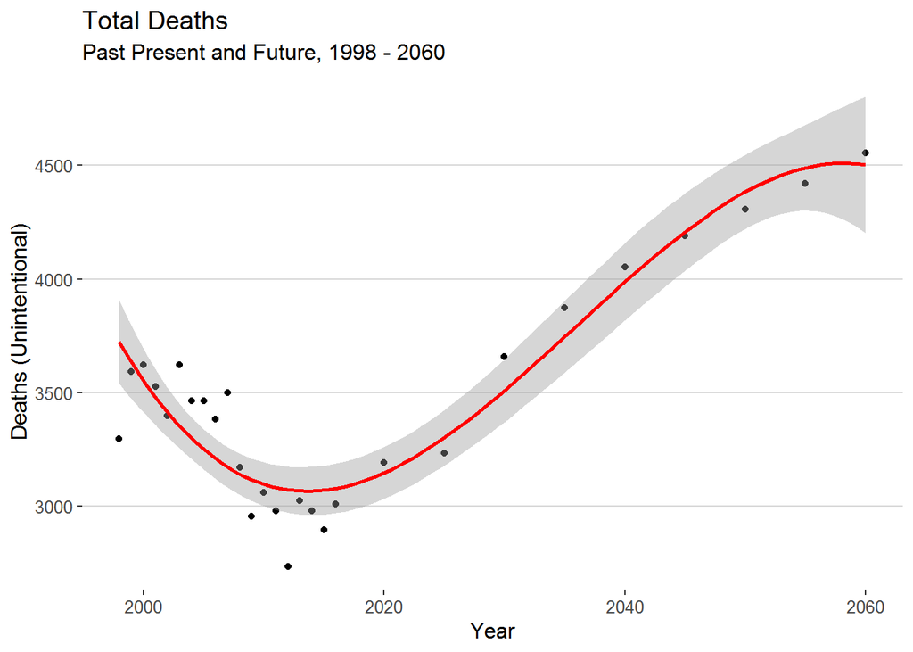

# What Can We Do?

## Redefine Success

With a potential leveling off of fire mortality rates coming due to an aging population, it is important to redefine what it means to be successful.

Perhaps your organization had a goal similar to:

*Reduce the number of fire fatalities by 25% over the course of the next five years.*

That goal could be restated to:

*Reduce the fire mortality rate for each of the major age groups by 25%.*

- *Children under 5*
- *Children between the ages of 5 and 17*
- *Adults between the ages of 18 and 35*
- *Adults between the ages of 36 and 74*
- *Adults over the age of 75*

For smaller communities where fatalities occur infrequently other metrics can be used such as structure fire rates where property loss was greater than 50% of value or even emergency call volume where an older adult is involved.

Goal setting shouldn’t be limited to age demographics. A details analysis should be done to determine what is important for **your** organization.

Perhaps other important demographics for your community such as income, substance abuse, or education should be taken into consideration.

## Resources to Affect Success

NFPA has many resources available through the program [Remimbering When](https://www.nfpa.org/Public-Education/Resources/Education-Programs/Remembering-When). This program focuses on solutions such as:

- Smoking outside.
- Give space heaters space.
- Smoke alarms save lives.
- Exercise regularly.
- Be aware of uneven surfaces.

It’s also important to establish relationships with your local organizations that can aid in reaching your older populations such as:

- Senior Centers
- Places of worship
- Meals on Wheels
- Hospitals and health clinics
- State aging counsel or commission
- Farmers markets
- State consumer protection groups

These partnerships should be accompanied by clearly defined mission and goals.

Your organization could develop a home safety checklist that includes items such as:

- Check extension cords
- Check for trip hazards
- Ensure there are two ways out
- Ensure the home as smoke alarms installed.

# Conclusion - Cheer Up

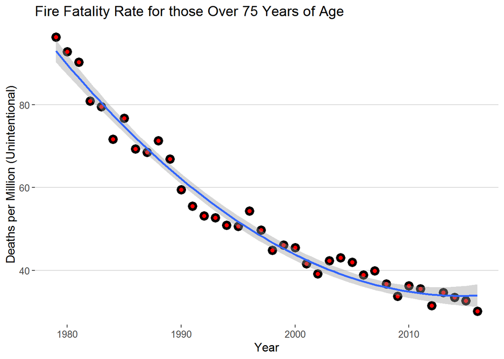

In addition, smoking (the leading cause of fire deaths for those over 65) is declining. According to the CDC smoking rates have declined from 20.9% of the population to 15.5% of the population.

It is important that we realize the impact that this shifting demographic can have on fire mortality. Simultaneously,we must also recognize ways that we can mitigate the effects this shift may have as well as define ways to measure success that allow us to see the progress that has been made.